# Fitting Multi-band Gaussian Processes Mira Model with RSTAN (HMC)

Zhenfeng Lin

11/20/2017 STAT605 project

# 1 Background

- Finding reliable periods eatimation of variable stars has been a hot area of interest in astronomy for at least four centuries.
- For example, Mira are typical variable stars whose periods can be used to make inference on $H_0$

# 2 Data

Observed Mira data format $\{(t_{bi},y_{bi,\sigma_{bi}}),\ i = 1,\ldots, n_b,\ b \in \{\text{`I',`H',`J',`K'}\}\}$.

- It’s periodic, but the folded period is not identical
- It’s multi-variate, but `I’-band has more points than others
- It has mesurement errors, but they are inhomogeneous
- It’s time-series data, but the measurement time points are not equally spaced
- It’s simple (maybe) for each light curves, but there are tons of such kind of stars

Two regions:

## 2.1 large magellanic cloud (LMC)

- third-closest galaxy to the Milky Way, about 50 kiloparsecs ($\approx$ 163,000 light-years)
- high-quality measurements
- $\approx$ 700 Miras

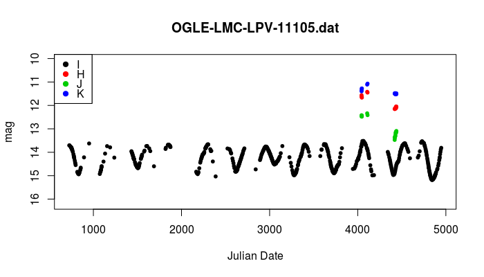

## 2.2 M33

- very far away from the Milky Way, 730 to 940 kiloparsecs ($\approx$ 2,379,000 to 3,064,400 light-years)
- poor quality data
- $\approx$ 2,000 stars

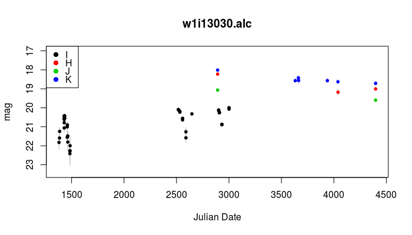

# 3 One-band model

For LMC data, we can only use I-band to get good results. He et al (2016) proposed a model as

for every fixed frequency $f$

$$\begin{split}
& y_{Ii} | m_I,\boldsymbol{\beta}_I, g_b(t_{bi}) \sim \mathcal{N}(g_I(t_{bi}), \sigma_{Ii}^2),\\
& g_I(t) = m_I + \mathbf{b}_f(t)^T\boldsymbol{\beta}_I + h_I(t), \\
& m_I \sim \mathcal{N}(m_{I0}, \sigma_{Im}^2),\
\boldsymbol{\beta}_I \sim \mathcal{N}(\mathbf{0},\sigma_I^2\mathbf{I} ),\\
& h_I(t)| \boldsymbol{\theta}_I \sim \mathcal{GP}(0,k_{\boldsymbol{\theta}_I} (t,t')). \\ \\
& k_{\boldsymbol{\theta}} (t,t') = \theta_1^2\exp\left(-\frac{(t-t')^2}{\theta_2^2}\right). \\
& \mathbf{b}_f(t) =(\cos(2\pi ft),\sin(2\pi ft))^T
\end{split} \tag{1}$$

In model (1), $\theta_1$ and $\theta_2$ are hyperparameters that are estimated using Quasi-Newton Method. Then they did a grid search on frequency $f$. Finally they picked the frequency that maximizes the profile likelihood.

Some examples

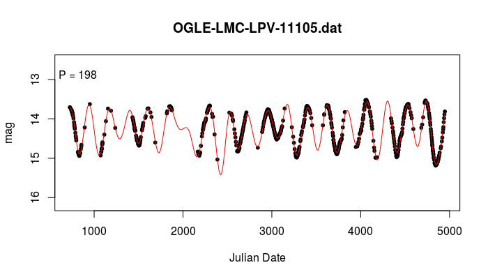

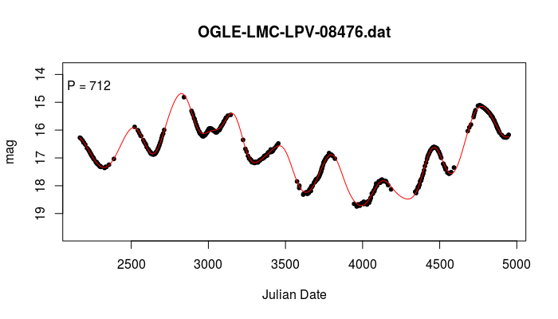

## 3.1 On M33

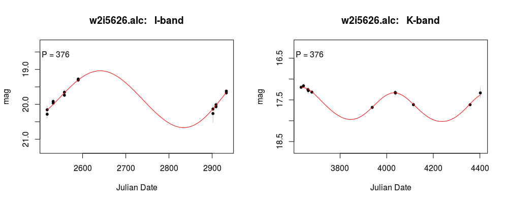

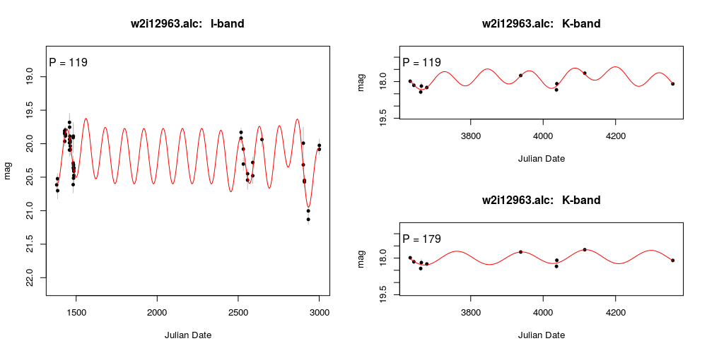

# 4 Scaling relation based on LMC

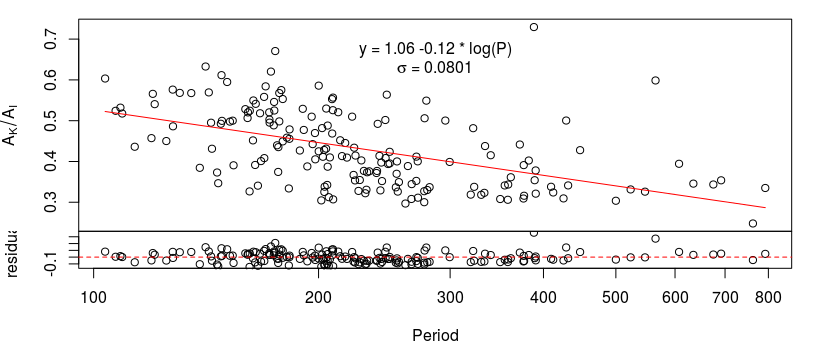

# 5 Two-band model

For each $f$,

$$\begin{split}
& y_{Ii} | m_I,\boldsymbol{\beta}_I, g_I(t_{Ii}) \sim \mathcal{N}(g_I(t_{Ii}), \sigma_{Ii}^2),\\
& g_I(t) = m_I + \mathbf{b}_f(t)^T\boldsymbol{\beta}_I + h_I(t), \\
& m_I \sim \mathcal{N}(m_{I0}, \sigma_{m}^2),\
\boldsymbol{\beta}_I \sim \mathcal{N}(\mathbf{0},\sigma_\beta^2\mathbf{I} ),\\
& h_I(t)| \boldsymbol{\theta} \sim \mathcal{GP}(0,k_{\boldsymbol{\theta}} (t,t')). \\ \\
& y_{Ki} | m_K,\boldsymbol{\beta}_K, g_K(t_{Ki}) \sim \mathcal{N}(g_K(t_{Ki}), \sigma_{Ki}^2),\\
& g_K(t) = m_K + \mathbf{b}_f(t)^T\boldsymbol{\beta}_K + h_K(t), \\
& m_K \sim \mathcal{N}(m_{K0}, \sigma_{m}^2),\
\boldsymbol{\beta}_K \sim \mathcal{N}(\mathbf{0},\color{red}{c_K^2}\sigma_\beta^2\mathbf{I} ),\\
& h_K(t)| \boldsymbol{\theta} \sim \mathcal{GP}(0,k_{\boldsymbol{\theta}} (t,t')), \\
& \color{red}{c_K = 1.06 + 0.12\log(f) + \delta,\ \ \ \delta \sim \mathcal{N}(0,0.08^2)} \\ \\
& k_{\boldsymbol{\theta}} (t,t') = \theta_1^2\exp\left(-\frac{(t-t')^2}{\theta_2^2}\right) \\
& \color{red}{\theta_1^2 \sim \text{HalfCauchy(0,5)}} \\
& \color{red}{\theta_2^{-2} \sim \text{HalfCauchy(0,5)}}
\end{split}
\tag{2}$$

Some marginal distirbutions:

$$\begin{split}
&\boldsymbol{y}_I|\theta, f \sim N(\mu_I, \Sigma_I), \\
&\boldsymbol{y}_K|\theta, f \sim N(\mu_K, \Sigma_K), \\
&\mu_I = m_{I0}\boldsymbol{1}, \mu_K = m_{K0}\boldsymbol{1},\\
&\Sigma_I = (\sigma_m^2 + \sigma_\beta^2\mathbf{b}_f(t_{Ii})^T\mathbf{b}_f(t_{Ij})+k_{\theta}(t_{Ii}, t_{Ij}) + \sigma_{Ii}^2\delta_{Ii,Ij})_{n_I\times n_I} \\
&\Sigma_K|c_K^2 = (\sigma_m^2 + \color{red}{c_K^2}\sigma_\beta^2\mathbf{b}_f(t_{Ki})^T\mathbf{b}_f(t_{Kj})+k_{\theta}(t_{Ki}, t_{Kj}) + \sigma_{Ki}^2\delta_{Ki,Kj})_{n_K\times n_K} \\
& \color{red}{c_K = 1.06 + 0.12\log(f) + \delta,\ \ \ \delta \sim \mathcal{N}(0,0.08^2)} \\
& \color{red}{\theta_1^2 \sim \text{HalfCauchy(0,5)})} \\
& \color{red}{\theta_2^{-2} \sim \text{HalfCauchy(0,5)})}
\end{split}
\tag{3}$$

## 5.1 Implementation with RSTAN (Hamiltonian Monte Carlo)

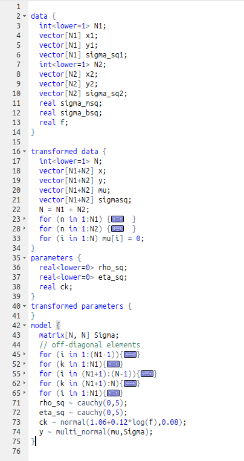

- 3 chains
- 200 iterations

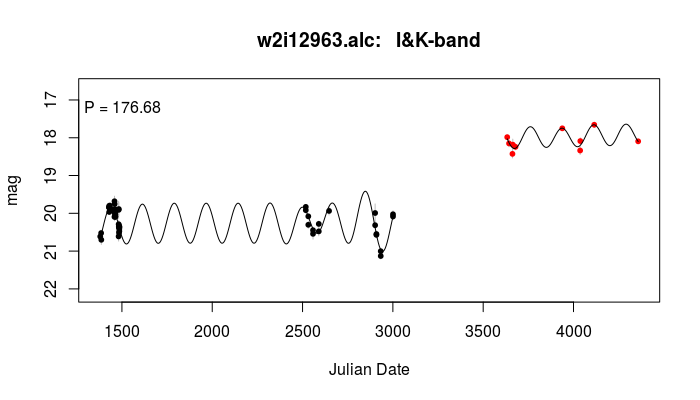

## 5.2 Comparison of one-band model and two-band model on 5000 simulated light curves (It’s a blind test!)

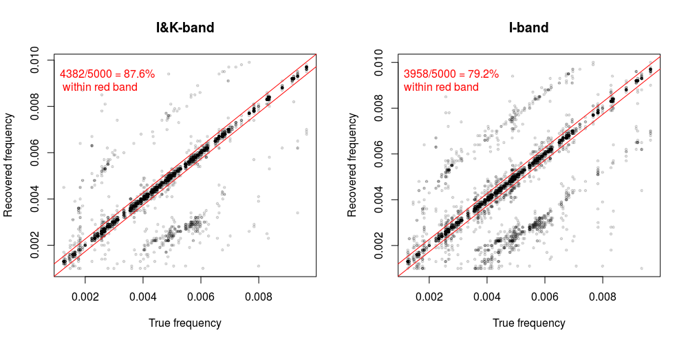

The red lines indicate $|\Delta f|<2.7E−4$.

[figure not shown]

[figure not shown]

[figure not shown]

# 6 Some notes (pls ignore this section)

## 6.1 Why using half-Cauchy?

The half-Cauchy has many properties; some are useful properties we may want in a prior.

A common choice for a prior on a scale parameter is the inverse gamma (not least, because it’s conjugate for some familiar cases). When a weakly informative prior is desired, very small parameter values are used.

The half-Cauchy is quite heavy tailed and it, too, may be regarded as fairly weakly informative in some situations. Gelman ([1] for example) advocates for half-t priors (including the half-Cauchy) over the inverse gamma because they have better behavior for small parameter values but only regards it as wealy informative when a large scale parameter is used*. Gelman has focused more on the half-Cauchy in more recent years. The paper by Polson and Scott [2] gives additional reasons for choosing the half-Cauchy in particular.

[1] A. Gelman (2006), “Prior distributions for variance parameters in hierarchical models” Bayesian Analysis, Vol. 1, N. 3, pp. 515–533 http://www.stat.columbia.edu/~gelman/research/published/taumain.pdf

[2] N. G. Polson and J. G. Scott (2012), “On the Half-Cauchy Prior for a Global Scale Parameter” Bayesian Analysis, Vol. 7, No. 4, pp. 887-902 https://projecteuclid.org/euclid.ba/1354024466